# GelmanHill Exercises Chapter 3

Kyle Wasserberger

Last Updated: 2019-12-05

## Exercise 3.9.1

#### Part A

Use R to fit a linear regression model predicting *y* from *x<sub>1</sub>*, *x<sub>2</sub>* using the first 40 data points in the file. Summarize the inferences and check the fit of your model.

```r
# load dataset
exercise3.9.1 <- read.csv('~/Box/R/GelmanHill_exercises/ARM_Data/pyth/exercise3.9.1.dat', sep = '')

# isolate rows 1-40 for model
mod.data <- exercise3.9.1[1:40,]
# summary.data.frame(mod.data)

# calculate and summarize model
mod <- lm(y ~ x1 + x2, data = mod.data)
display(mod)
```

```
lm(formula = y ~ x1 + x2, data = mod.data)
            coef.est coef.se
(Intercept) 1.32     0.39
x1          0.51     0.05
x2          0.81     0.02
---
n = 40, k = 3
residual sd = 0.90, R-Squared = 0.97
```

Model summary indicates large proportion of outcome variability (97%) is a accounted for by a linear combination of *x<sub>1</sub>* and *x<sub>2</sub>*. Residual standard deviation is also small.

#### Part B

Display the estimated model graphically

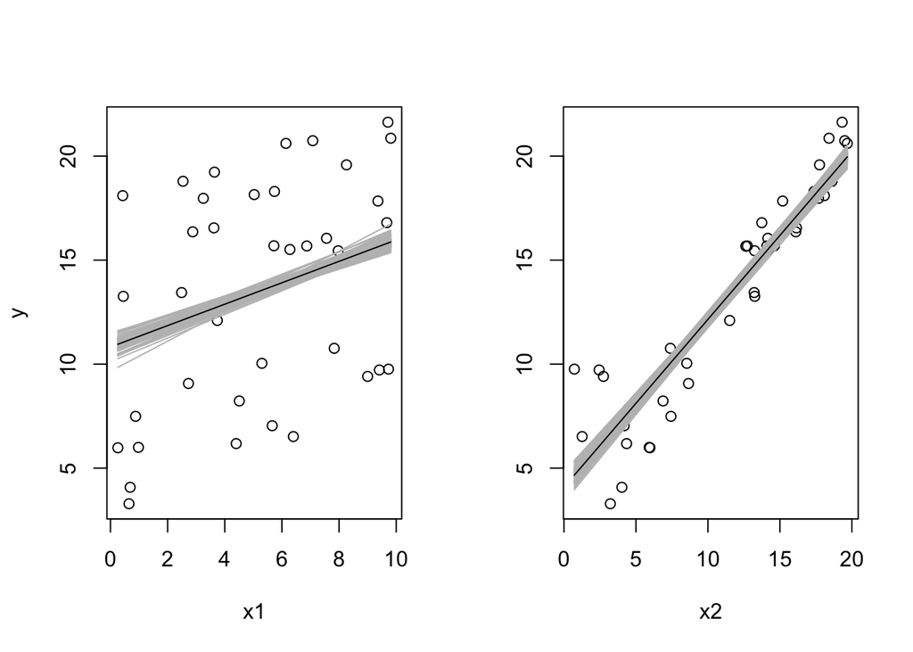

```r
# setup 1x2 plotting space
par(mfrow = c(1,2))

#simulate model (100)
mod.sim <- sim(mod)

# first plot
plot(x = mod.data$x1, y = mod.data$y,
     xlab = "x1", ylab = "y")

# simulate y against x1 with x2 held to its mean value
for (i in 1:100) {
curve(cbind(1, x, mean(mod.data$x2)) %*% mod.sim@coef[i,], col = "grey", add = TRUE)
}

curve(cbind(1,x, mean(mod.data$x2)) %*% mod$coefficients, col = "black", add = TRUE)

# add second plot
plot(x = mod.data$x2, y = mod.data$y,
     xlab = "x2", ylab = "")

# simulate y against x2 with x1 held to its mean value
for (i in 1:100) {
curve(cbind(1, mean(mod.data$x1), x) %*% mod.sim@coef[i,], col = "grey", add = TRUE)
}

curve(cbind(1, mean(mod.data$x1), x) %*% mod$coefficients, col = "black", add = TRUE)
```

#### Part C

Make and interpret residual plot.

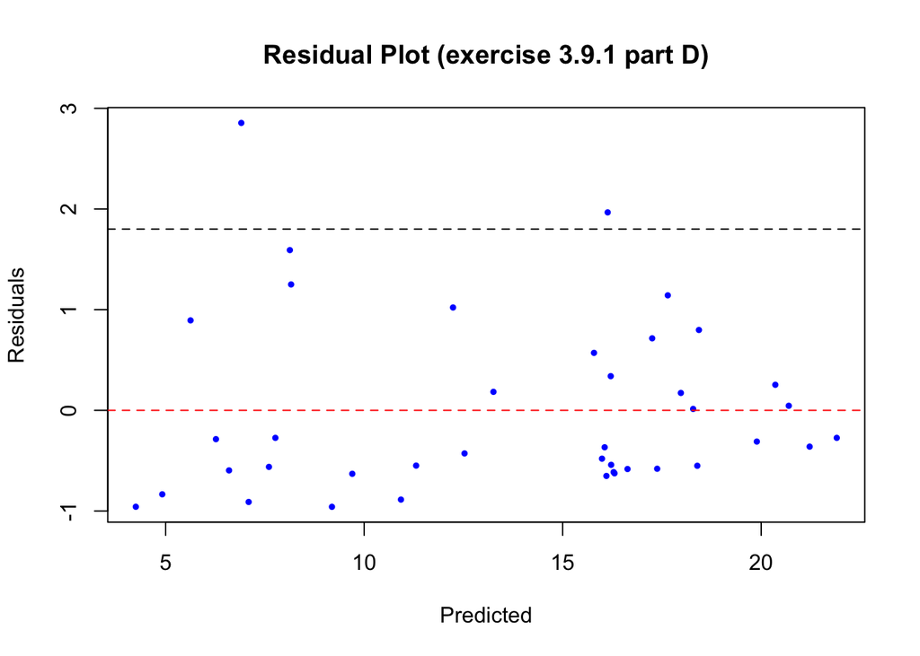

```r
preds <- predict(mod)
resids <- resid(mod)
resid.error <- sigma(mod)

# black line = +2 resid sd
residual.plot(Expected = preds, Residuals = resids, sigma = resid.error,
              main = "Residual Plot (exercise 3.9.1 part D)")
```

Greater proportion of residuals appear below zero indicating assumptions may be in violation.

#### Part D

Make predictions for the remaining 20 data points.

```r
predict.data <- exercise3.9.1[41:60,]

mod.predicts <- predict(mod, predict.data, interval = "prediction", level = 0.95)

head(mod.predicts)
```

```
         fit       lwr       upr
41 14.812484 12.916966 16.708002
42 19.142865 17.241520 21.044211
43  5.916816  3.958626  7.875005
44 10.530475  8.636141 12.424809
45 19.012485 17.118597 20.906373
46 13.398863 11.551815 15.245911
```

## Exercise 3.9.2

We can predict log(earnings) from log(height) for certain population…

Hints:

- A person who is 66 inches tall is predicted to make $30,000
- Every 1% increase in height = 0.8% increase in earnings
- Earnings of 95% of people fall within 1.1 units of predicted values

#### Part A

Give regression line equation and residual standard deviation of the regression

From the question, we know that:

$$ln(y) = C+\beta*ln(x_1) \tag{1}$$

Solving for *y* we get:

$$y=e^c * e^{\beta*ln(x_1)} \tag{2}$$

From the second hint we know that

$$(1.008)y=e^c * e^{\beta*ln(1.01x_1)} \tag{3}$$

We can now divide by *y* (and its equivalent from eq 2) to get:

$$1.008=\frac{{e^c*e^{\beta*ln(1.01x_1)}}}{{e^c * e^{\beta*ln(x_1)}}} \tag{4}$$

Cancelling out like terms and simplifying logs we are left with:

$$1.008=\frac{(1.01x_1)^\beta}{(x_1)^\beta} \tag{5}$$

More simplifying and cancelling gives us:

$$1.008=1.01^\beta \tag{6}$$

Finally, we have:

$$\beta=\frac{ln(1.008)}{ln(1.01)} \tag{7}$$

We can now calculate $\beta$ as:

```r
# in R, the log function is the natural log
beta <- log(1.008)/log(1.01)
round(beta, digits = 3)
```

```
[1] 0.801
```

We can then plug $\beta$ and the given values from hint 1 for *y* and *x<sub>1</sub>* into our original regression formula solved for C

$$C=ln(30000)-0.801*ln(66) \tag{8}$$

```r
c <- log(30000)-beta*log(66)
round(c, digits = 3)
```

```
[1] 6.954
```

Plugging c into the original equation we finally have:

$$ln(y)=6.954+0.801*ln(x_1) \tag{9}$$

Double checking with our given information using equation 2 we get:

```r
exp(c)*exp(beta*log(66))
```

```
[1] 30000
```

#### Part B

Standard deviation of log heights = 5%. What is the *R^2* of the regression?

## Exercise 3.9.3

#### Part A

Find out what happens when you regress one randomly generated variable on another. Is the predictor slope significant?

```r
var1 <- rnorm(1000,0,1)
var2 <- rnorm(1000,0,1)
mod <- lm(var2 ~ var1)
display(mod)
```

```
lm(formula = var2 ~ var1)
            coef.est coef.se
(Intercept)  0.03     0.03
var1        -0.02     0.03
---
n = 1000, k = 2
residual sd = 0.98, R-Squared = 0.00
```

#### Part B

Run a simulation of part A (100X). How many of the z-scores are statistically significant?

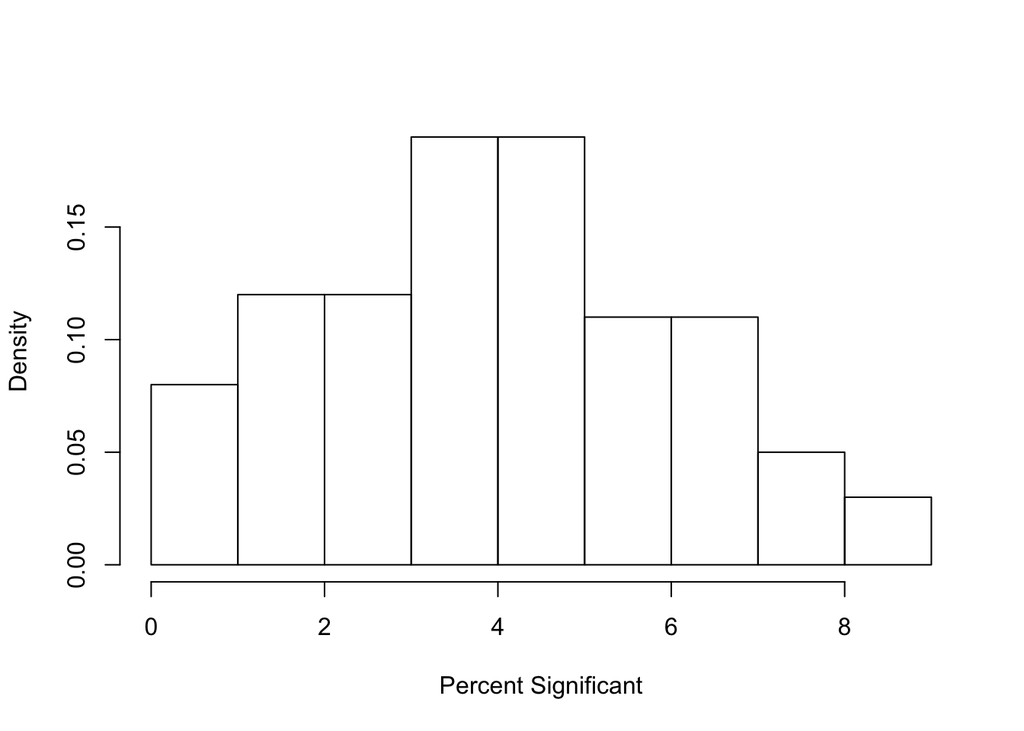

```r
# set up empty vectors
z.scores <- data.frame(score = rep(NA,100))
percent.sig <- data.frame(percent_sig = rep(NA,100))

for (k in 1:100) {

    for (j in 1:100) {
    var1 <- rnorm(1000,0,1)
    var2 <- rnorm(1000,0,1)
    mod <- lm(var2 ~ var1)
    z.scores[j,1] <- coef(mod)[2]/se.coef(mod)[2]
    z.scores$sig <- ifelse(z.scores$score >= 2 | z.scores$score <= -2,1,0)
    sig <- (sum(z.scores$sig, na.rm = TRUE)/length(z.scores$sig))*100
    j <- 1}

  percent.sig[k,1] <- sig
}


# basic histogram of %significant scores over 100 simulations
psig_hist <- hist(percent.sig$percent_sig,
                  xlab = "Percent Significant",
                  main = "", probability = TRUE)
```

```r
summary(percent.sig$percent_sig)
```

```
   Min. 1st Qu.  Median    Mean 3rd Qu.    Max.
   0.00    3.00    4.00    4.47    6.00    9.00
```

On average, 4.47 *z*-scores were statistically significant (range = 0:9).

## Exercise 3.9.4

#### Part A

Fit a regression of child test scores on mother’s age, graph the data and fitted model, check assumptions, and interpret the slope coefficient.

```r
kidiq <- read_dta("ARM_Data/child.iq/kidiq.dta")

mod <- lm(kid_score ~ mom_age, data = kidiq)
display(mod)
```

```
lm(formula = kid_score ~ mom_age, data = kidiq)
            coef.est coef.se
(Intercept) 70.96     8.31
mom_age      0.70     0.36
---
n = 434, k = 2
residual sd = 20.35, R-Squared = 0.01
```

Model summary indicates very little predictive ability for mother’s age on child test score (*r^2* = 0.01; large residual SD). Slope coefficient = 0.70 indicating that for a 1-unit increase in mother age we would predict a 0.7-unit increase in child test score. I.E. two identical children whose mothers are one year apart in age would have test score differences of 0.7 points.

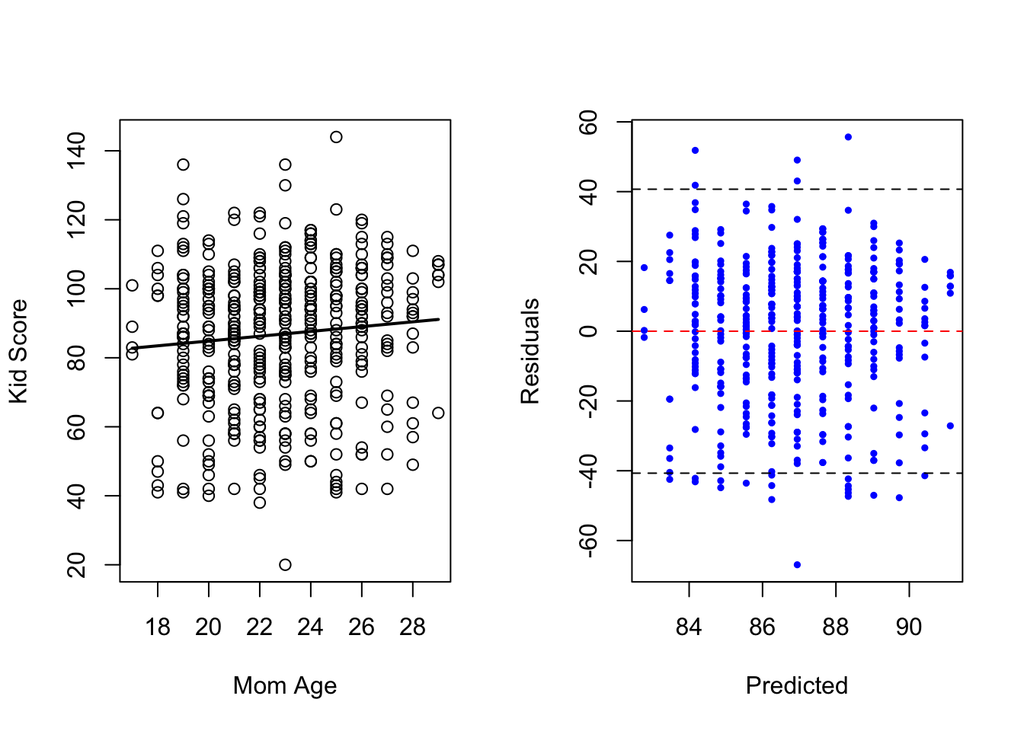

```r
par(mfrow = c(1,2))
plot(kidiq$mom_age, kidiq$kid_score,
     xlab = "Mom Age", ylab = "Kid Score")
  curve(cbind(1,x) %*% coef(mod), lwd = 2, add = TRUE)

resids <- resid(mod)
preds <- predict(mod)
sig <- sigma(mod)

residual.plot(Expected = preds, Residuals = resids, sigma = sig, main = "")
```

The most basic way of checking regression assumptions is to look for trends in the predicted vs. residual plot. We see no strong trends here.

Since test score increases with mother’s age, we would recommend mothers give birth as late as possible. However, this recommendation assumes the trend observed in the sample continues for unobserved mother ages (unlikely).

#### Part B

Repeat regression including mother education. Interpret both slope coefficients. Have your conclusions about the timing of birth changed?

```r
kidiq <- read_dta("ARM_Data/child.iq/kidiq.dta")

mod <- lm(kid_score ~ mom_age + mom_hs, data = kidiq)
display(mod)
```

```
lm(formula = kid_score ~ mom_age + mom_hs, data = kidiq)
            coef.est coef.se
(Intercept) 70.48     8.11
mom_age      0.33     0.36
mom_hs      11.31     2.38
---
n = 434, k = 3
residual sd = 19.86, R-Squared = 0.06
```

Adding mother education only slightly improved our model predictive ability. However, the slope coeffient for age decreased from 0.7 to 0.3 suggesting the ifluence of mother age decreases if you also know whether the mom went to high-school. The positive slope coefficient for mother education indicates that babies of mothers who graduated high-school generally score higher than babies from mothers who did not graduate high-school (average difference of 11.31 points) .